# Modelo baseline de pronóstico

Ventas de productos eléctricos y electrónicos en Northern Territory

Author

Equipo Proyecto M1 3

## Objetivo

Construir y evaluar un modelo baseline para pronosticar las ventas minoristas mensuales de productos eléctricos y electrónicos en Northern Territory, Australia.

## Serie asignada

- **Equipo:** Proyecto M1 3
- **Estado:** Northern Territory
- **Industria:** Electrical and electronic goods retailing
- **Series ID:** `A3349598V`
- **Frecuencia:** mensual

## Preparación del entorno

```r
library(fpp3)
```

## Obtención de la serie

```r
electrical_serie <- aus_retail |>
  filter(`Series ID` == "A3349598V")

electrical_serie
```

```
# A tsibble: 369 x 5 [1M]
# Key:       State, Industry [1]
   State              Industry                    `Series ID`     Month Turnover
   <chr>              <chr>                       <chr>           <mth>    <dbl>
 1 Northern Territory Electrical and electronic … A3349598V   1988 abr.      1.7
 2 Northern Territory Electrical and electronic … A3349598V   1988 may.      1.8
 3 Northern Territory Electrical and electronic … A3349598V   1988 jun.      1.5
 4 Northern Territory Electrical and electronic … A3349598V   1988 jul.      1.6
 5 Northern Territory Electrical and electronic … A3349598V   1988 ago.      1.6
 6 Northern Territory Electrical and electronic … A3349598V   1988 sep.      1.8
 7 Northern Territory Electrical and electronic … A3349598V   1988 oct.      1.8
 8 Northern Territory Electrical and electronic … A3349598V   1988 nov.      1.8
 9 Northern Territory Electrical and electronic … A3349598V   1988 dic.      2.8
10 Northern Territory Electrical and electronic … A3349598V   1989 ene.      1.8
# ℹ 359 more rows
```

## Verificación de la serie

```r
electrical_serie |>
  distinct(State, Industry, `Series ID`)
```

```
# A tibble: 1 × 3
  State              Industry                                  `Series ID`
  <chr>              <chr>                                     <chr>
1 Northern Territory Electrical and electronic goods retailing A3349598V
```

```r
electrical_serie |>
  summarise(
    fecha_inicial = min(Month),
    fecha_final = max(Month),
    observaciones = n()
  )
```

```
# A tsibble: 369 x 4 [1M]
       Month fecha_inicial fecha_final observaciones
       <mth>         <mth>       <mth>         <int>
 1 1988 abr.     1988 abr.   1988 abr.             1
 2 1988 may.     1988 may.   1988 may.             1
 3 1988 jun.     1988 jun.   1988 jun.             1
 4 1988 jul.     1988 jul.   1988 jul.             1
 5 1988 ago.     1988 ago.   1988 ago.             1
 6 1988 sep.     1988 sep.   1988 sep.             1
 7 1988 oct.     1988 oct.   1988 oct.             1
 8 1988 nov.     1988 nov.   1988 nov.             1
 9 1988 dic.     1988 dic.   1988 dic.             1
10 1989 ene.     1989 ene.   1989 ene.             1
# ℹ 359 more rows
```

## Análisis exploratorio

Antes de construir el modelo de pronóstico, se analiza el comportamiento histórico de la serie para identificar tendencia, estacionalidad, cambios en la variabilidad y otras observaciones que surjan.

### Promedio, Mediana, Min y Max Ventas de la Serie

```r
electrical_serie |>
  as_tibble() |>
  summarise(
    venta_minima = min(Turnover, na.rm = TRUE),
    venta_promedio = mean(Turnover, na.rm = TRUE),
    mediana = median(Turnover, na.rm = TRUE),
    venta_maxima = max(Turnover, na.rm = TRUE)
  )
```

```
# A tibble: 1 × 4
  venta_minima venta_promedio mediana venta_maxima
         <dbl>          <dbl>   <dbl>        <dbl>
1          1.5           9.34     8.8         26.5
```

La serie registra ventas mensuales entre 1.5 y 26.5 millones de dólares australianos. El promedio mensual es de 9.34 millones y la mediana es de 8.8 millones. Que el promedio sea ligeramente superior a la mediana indica que puede haber valores elevados.

### Evolución histórica

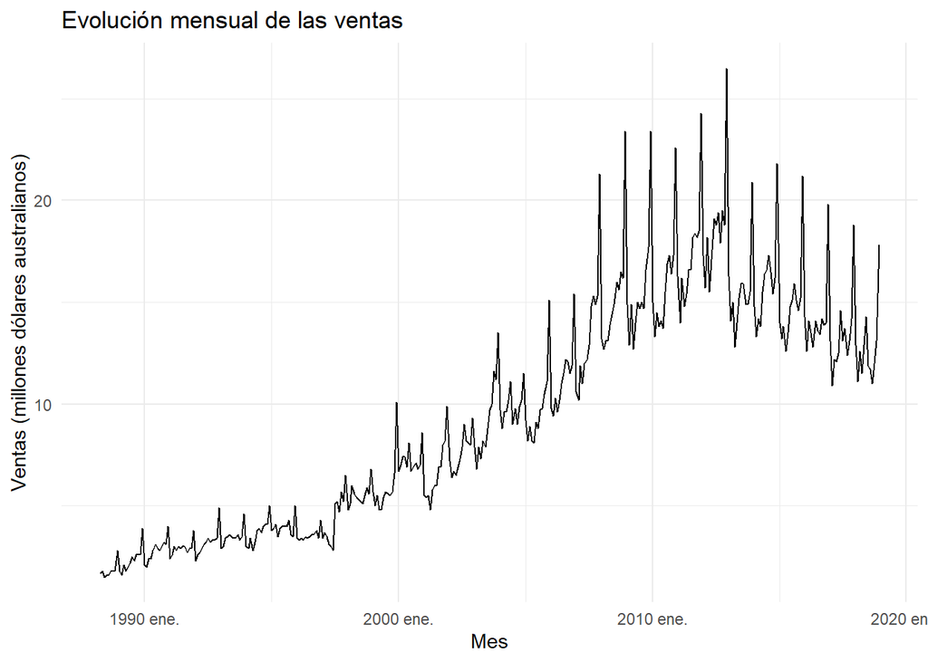

```r
electrical_serie |>
  autoplot(Turnover) +
  labs(
    title = "Evolución mensual de las ventas",
    x = "Mes",
    y = "Ventas (millones dólares australianos)"
  ) +
  theme_minimal()
```

La serie presenta una tendencia creciente desde aproximadamente 1988 hasta 2012–2013. A partir de ese periodo se observa una disminución en el nivel de las ventas y posteriormente un comportamiento cambiante. También se identifican picos pronunciados que se repiten regularmente, lo cual sugiere la presencia de estacionalidad anual.

### Patrón estacional

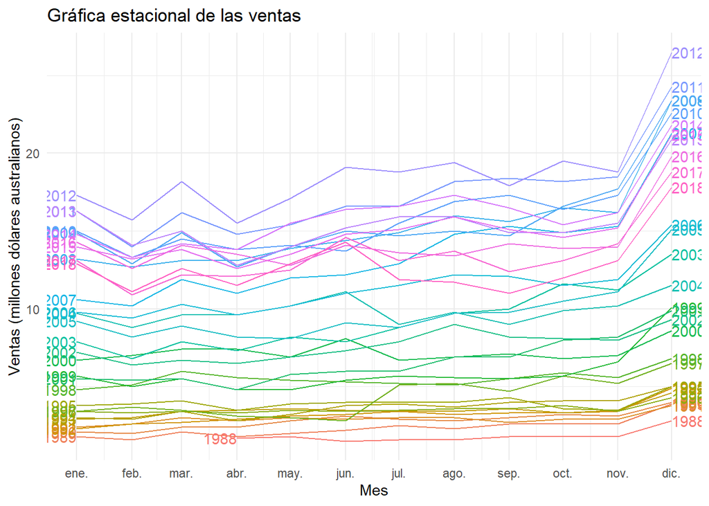

```r
electrical_serie |>
  gg_season(Turnover, labels = "both") +
  labs(
    title = "Gráfica estacional de las ventas",
    x = "Mes",
    y = "Ventas (millones dólares australianos)"
  ) +
  theme_minimal()
```

Esta gráfica muestra un patrón anual marcado. Diciembre presenta consistentemente las ventas más altas y, al contrario, febrero y abril suelen registrar niveles menores. Aunque la magnitud de las ventas cambia entre años, la forma general del patrón mensual se repite, lo que confirma la existencia de estacionalidad anual.

### Comparación por mes

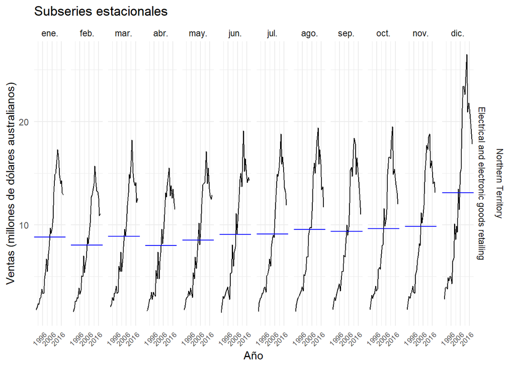

```r
electrical_serie |>
  gg_subseries(Turnover) +
  scale_x_yearmonth(
    date_breaks = "10 years",
    date_labels = "%Y"
  ) +
  labs(
    title = "Subseries estacionales",
    x = "Año",
    y = "Ventas (millones de dólares australianos)"
  ) +
  theme_minimal() +
  theme(
    axis.text.x = element_text(
      angle = 45,
      hjust = 1,
      size = 7
    )
  )
```

Las subseries estacionales confirman que diciembre posee el promedio histórico más alto de ventas y una variabilidad considerablemente mayor que los demás meses. Febrero y abril presentan los promedios mensuales más bajos, mientras que los demás promedios tienden a incrementarse hacia los últimos meses del año.

### Autocorrelación

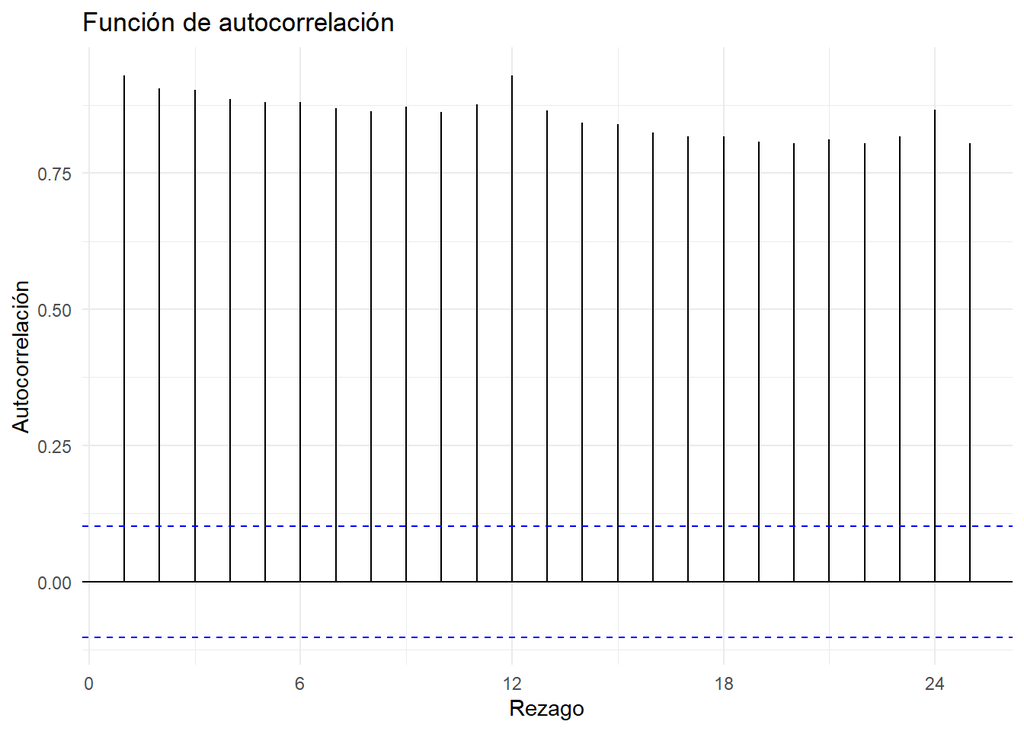

```r
electrical_serie |>
  ACF(Turnover) |>
  autoplot() +
  labs(
    title = "Función de autocorrelación",
    x = "Rezago",
    y = "Autocorrelación"
  ) +
  theme_minimal()
```

Esta función nos muestra valores positivos y elevados que disminuyen lentamente conforme aumenta el rezago. Esto indica una fuerte dependencia temporal y confirma que la serie no fluctúa aleatoriamente alrededor de un nivel constante. Los incrementos observados en los rezagos 12 y 24 evidencian que las ventas de un mes están relacionadas con las del mismo mes en años anteriores, confirmando una periodicidad anual.

### Conclusiones EDA

- La serie presenta crecimiento hasta aproximadamente 2012–2013 y después una disminución.
- Existe una estacionalidad anual fuerte, con las mayores ventas en diciembre.
- La variabilidad aumenta junto con el nivel de ventas.
- La función de autocorrelación muestra dependencia temporal y estacionalidad en los rezagos 12 y 24.

## Estabilización de la varianza

En la serie original se observa que las fluctuaciones tienen mayor amplitud durante los años con ventas más altas. Esto nos dice que una transformación podría ayudar a estabilizar la variabilidad.

Para elegir el parámetro de Box-Cox se utiliza el método de Guerrero. Se excluyen los últimos 24 meses del cálculo, ya que se reservarán para evaluar el pronóstico.

```r
lambda <- electrical_serie |>
  slice_head(n = nrow(electrical_serie) - 24) |>
  features(Turnover, guerrero) |>
  pull(lambda_guerrero)

lambda
```

```
[1] 0.118152
```

Después observamos el BoxCox

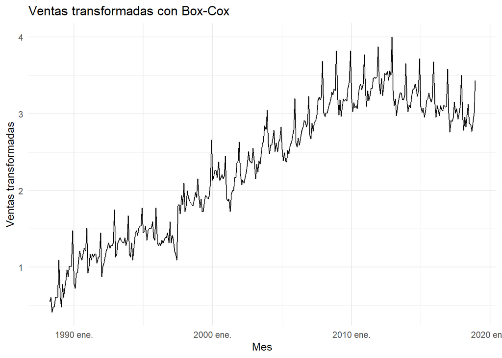

```r
electrical_serie |>
  autoplot(box_cox(Turnover, lambda)) +
  labs(
    title = "Ventas transformadas con Box-Cox",
    x = "Mes",
    y = "Ventas transformadas"
  ) +
  theme_minimal()
```

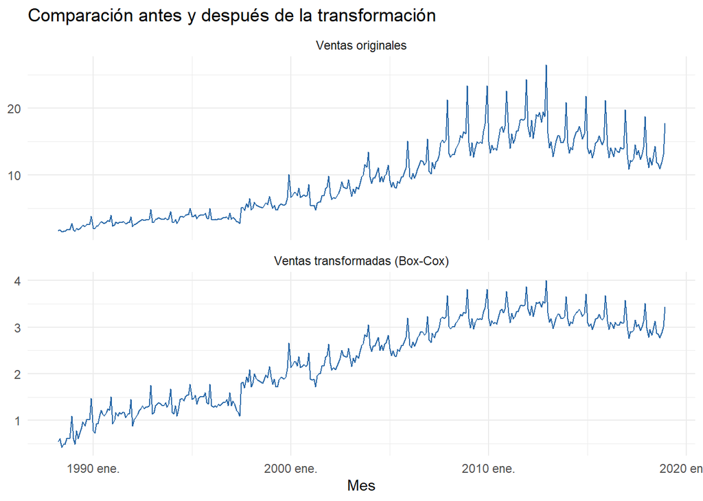

```r
electrical_serie |>
  mutate(Transformada = box_cox(Turnover, lambda)) |>
  as_tibble() |>
  pivot_longer(
    cols = c(Turnover, Transformada),
    names_to = "Escala",
    values_to = "Valor"
  ) |>
  mutate(
    Escala = recode(
      Escala,
      Turnover = "Ventas originales",
      Transformada = "Ventas transformadas (Box-Cox)"
    )
  ) |>
  ggplot(aes(x = Month, y = Valor)) +
  geom_line(color = "#2767A7") +
  facet_wrap(~ Escala, ncol = 1, scales = "free_y") +
  labs(
    title = "Comparación antes y después de la transformación",
    x = "Mes",
    y = NULL
  ) +
  theme_minimal()
```

El método de Guerrero estimó λ = 0.118152. En la serie original, la amplitud de las fluctuaciones aumenta cuando el nivel de ventas es mayor. Después de aplicar la transformación Box-Cox, los picos de los años con ventas más altas se reducen y la variabilidad se observa más uniforme a lo largo del tiempo.

## Descomposición STL

Aplicamos STL a las ventas transformadas con Box-Cox para separar la serie en tres componentes: tendencia, estacionalidad y residuo.

```r
stl_entrenamiento <- electrical_serie |>
  slice_head(n = nrow(electrical_serie) - 24) |>
  model(
    STL(box_cox(Turnover, lambda) ~ season(window = "periodic"))
  )

componentes_stl <- components(stl_entrenamiento)
```

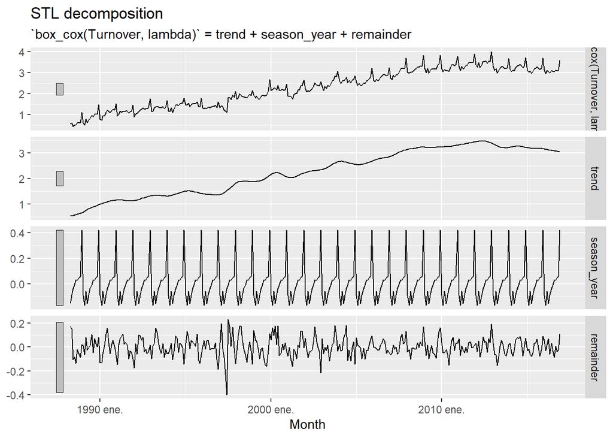

```r
componentes_stl |>
  autoplot()
```

## División de entrenamiento y prueba

```r
entrenamiento <- electrical_serie |>
  slice_head(n = nrow(electrical_serie) - 24)

prueba <- electrical_serie |>
  slice_tail(n = 24)
```

## Modelo baseline

```r
modelo_baseline <- entrenamiento |>
  model(
    snaive = decomposition_model(
      STL(box_cox(Turnover, lambda) ~ season(window = "periodic")),
      SNAIVE(season_adjust)
    ),
    drift = decomposition_model(
      STL(box_cox(Turnover, lambda) ~ season(window = "periodic")),
      RW(season_adjust ~ drift())
    )
  )

modelo_baseline
```

```
# A mable: 1 x 4
# Key:     State, Industry [1]
  State             Industry                    snaive                     drift
  <chr>             <chr>                      <model>                   <model>
1 Northern Territo… Electri… <STL decomposition model> <STL decomposition model>
```

Se ajustaron dos modelos baseline utilizando únicamente el conjunto de entrenamiento. Ambos emplean STL para separar la estacionalidad y modelan la serie ajustada estacionalmente. SNAIVE() utiliza el valor de la misma temporada del año anterior, mientras que RW(drift = TRUE) incorpora una tendencia promedio.

## Evaluación

Generamos pronósticos para los 24 meses reservados y los comparamos con las ventas observadas.

```r
pronosticos_prueba <- modelo_baseline |>
  forecast(h = "24 months")

pronosticos_prueba
```

```
# A fable: 48 x 6 [1M]
# Key:     State, Industry, .model [2]
   State              Industry            .model     Month        Turnover .mean
   <chr>              <chr>               <chr>      <mth>          <dist> <dbl>
 1 Northern Territory Electrical and ele… snaive 2017 ene. t(N(3.1, 0.05))  14.5
 2 Northern Territory Electrical and ele… snaive 2017 feb.   t(N(3, 0.05))  12.8
 3 Northern Territory Electrical and ele… snaive 2017 mar. t(N(3.1, 0.05))  14.3
 4 Northern Territory Electrical and ele… snaive 2017 abr.   t(N(3, 0.05))  13.7
 5 Northern Territory Electrical and ele… snaive 2017 may.   t(N(3, 0.05))  13.0
 6 Northern Territory Electrical and ele… snaive 2017 jun. t(N(3.1, 0.05))  14.3
 7 Northern Territory Electrical and ele… snaive 2017 jul. t(N(3.1, 0.05))  13.8
 8 Northern Territory Electrical and ele… snaive 2017 ago.   t(N(3, 0.05))  13.6
 9 Northern Territory Electrical and ele… snaive 2017 sep. t(N(3.1, 0.05))  14.4
10 Northern Territory Electrical and ele… snaive 2017 oct. t(N(3.1, 0.05))  14.1
# ℹ 38 more rows
```

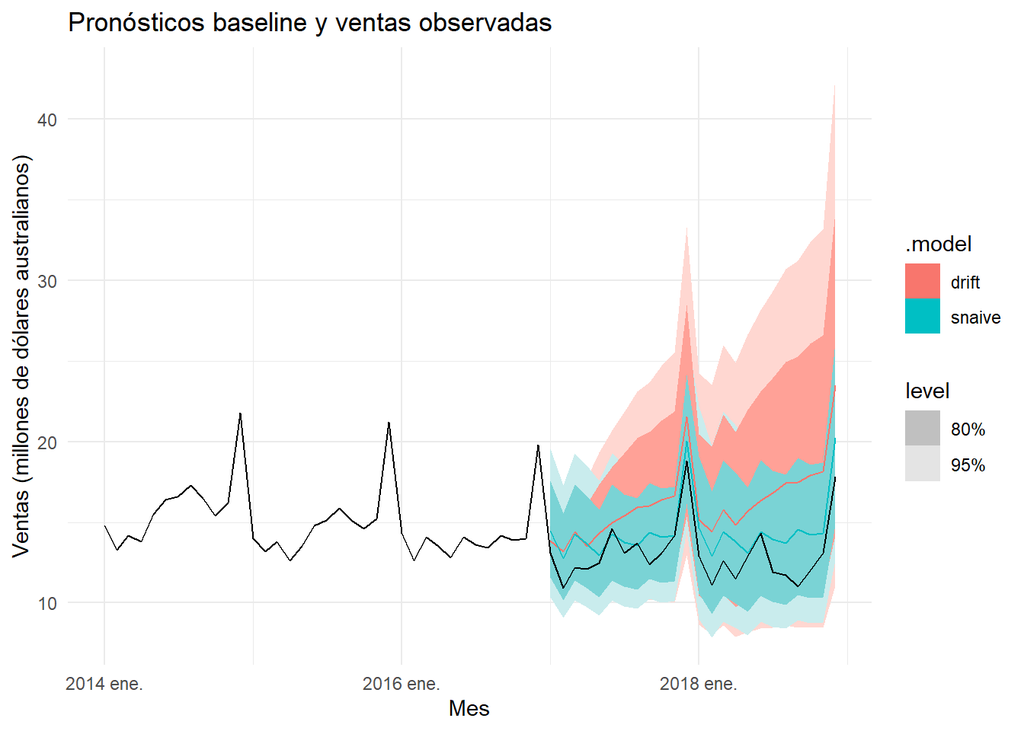

```r
pronosticos_prueba |>
  autoplot(
    electrical_serie |>
      filter(Month >= yearmonth("2014 Jan"))
  ) +
  labs(
    title = "Pronósticos baseline y ventas observadas",
    x = "Mes",
    y = "Ventas (millones de dólares australianos)"
  ) +
  theme_minimal()
```

En la gráfica, `snaive` reproduce mejor las subidas stacionales de las ventas observadas. En cambio, `drift` tiende a pronosticar valores cada vez más altos y sus intervalos de predicción se amplíanconsiderablemente conforme avanza el horizonte.

```r
metricas_prueba <- accuracy(
  pronosticos_prueba,
  electrical_serie
)

metricas_prueba |>
  select(.model, RMSE, MAE, MASE)
```

```
# A tibble: 2 × 4
  .model  RMSE   MAE  MASE
  <chr>  <dbl> <dbl> <dbl>
1 drift   3.57  3.18  2.86
2 snaive  1.67  1.42  1.28
```

Para evaluar los 24 meses de prueba utilizamos MASE como métrica principal, porque compara el error con una referencia estacional calculada a partir del entrenamiento. También reportamos MAE porque expresa cuánto se alejan, en promedio, las ventas pronosticadas de las observadas en la misma unidad de la serie. Añadimos RMSE porque da mayor peso a los errores grandes, algo útil para detectar fallas en una serie con picos pronunciados como los de diciembre. Las tres métricas favorecen a snaive: obtuvo un MASE de 1.28, un MAE de 1.42 y un RMSE de 1.67, frente a 2.86, 3.18 y 3.57 para drift. Por ello lo elegimos como el mejor baseline entre los dos evaluados, aunque su MASE mayor que 1 muestra que todavía hay margen para mejorar la precisión.

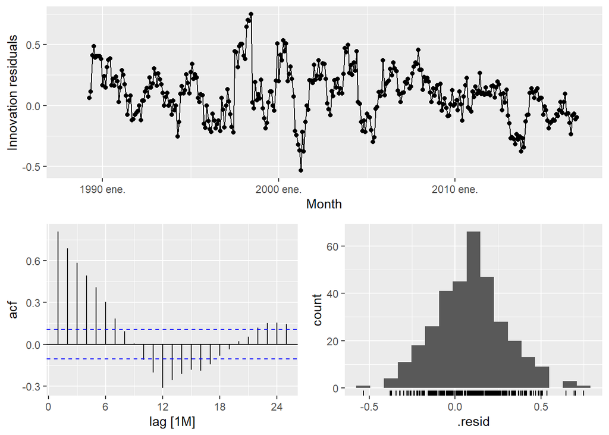

```r
modelo_baseline |>
  select(snaive) |>
  gg_tsresiduals()
```

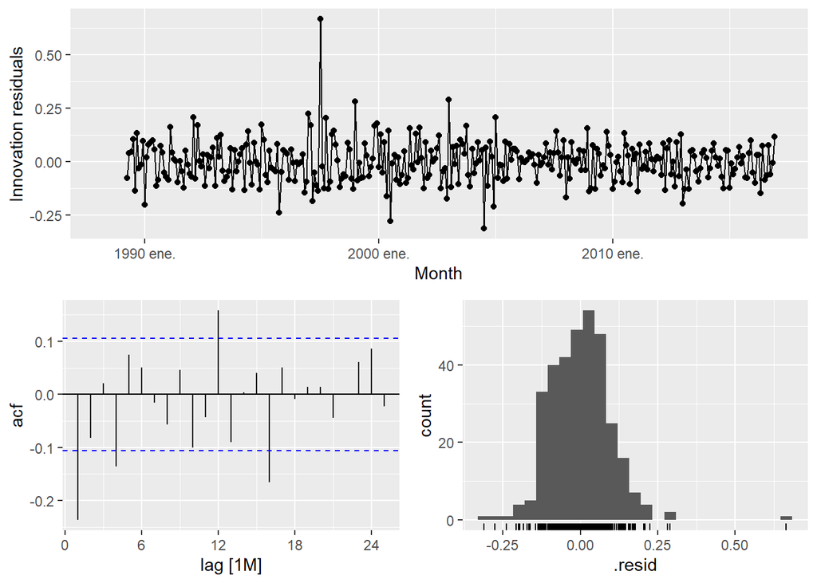

```r
modelo_baseline |>
  select(drift) |>
  gg_tsresiduals()
```

**Residuales de `snaive`.** Aunque este modelo obtuvo los menores errores en prueba, sus residuales muestran periodos consecutivos por encima o por debajo de cero. Además, varias barras de la función de autocorrelación superan las bandas de referencia, sobre todo en los primeros rezagos y cerca del rezago 12. Esto sugiere que el modelo aún deja patrones temporales sin explicar y que sus residuales no se comportan completamente como ruido blanco.

**Residuales de `drift`.** Los residuales se concentran más alrededor de cero y muestran menos autocorrelaciones destacadas que los de `snaive`, aunque algunas barras todavía superan las bandas de referencia. Por ello, tampoco podemos afirmar que toda la dependencia temporal haya desaparecido. A pesar de este diagnóstico visual, `drift` obtuvo errores mayores en los 24 meses de prueba, por lo que no fue el mejor modelo para pronosticar este periodo.

### Conclusiones Evaluación

La evaluación sobre los 24 meses de prueba mostró que snaive pronosticó con mayor precisión que drift: obtuvo un MAE de 1.42 y un RMSE de 1.67, frente a 3.18 y 3.57, respectivamente. La gráfica también muestra que snaive siguió mejor las variaciones estacionales observadas, mientras que drift tendió a pronosticar ventas demasiado altas conforme avanzó el horizonte. Por ello, elegimos snaive como el mejor baseline de los dos evaluados. Sin embargo, la autocorrelación presente en sus residuales indica que todavía quedan patrones sin explicar, por lo que su ajuste puede mejorarse en trabajos posteriores.

## Pronóstico final

Durante la evaluación, `snaive` obtuvo los menores errores en los 24 meses reservados para prueba. Para producir el pronóstico final, se ajusta de nuevo el mismo tipo de modelo usando todas las observaciones disponibles.

```r
lambda_final <- electrical_serie |>
  features(Turnover, guerrero) |>
  pull(lambda_guerrero)

modelo_final <- electrical_serie |>
  model(
    snaive = decomposition_model(
      STL(box_cox(Turnover, lambda_final) ~ season(window = "periodic")),
      SNAIVE(season_adjust)
    )
  )

lambda_final
```

```
[1] 0.1276948
```

```r
modelo_final
```

```
# A mable: 1 x 3
# Key:     State, Industry [1]
  State              Industry                                             snaive
  <chr>              <chr>                                               <model>
1 Northern Territory Electrical and electronic goods … <STL decomposition model>
```

```r
pronostico_final <- modelo_final |>
  forecast(h = "24 months")

pronostico_final |>
  as_tibble() |>
  select(Month, .mean)
```

```
# A tibble: 24 × 2
       Month .mean
       <mth> <dbl>
 1 2019 ene.  13.0
 2 2019 feb.  11.2
 3 2019 mar.  12.7
 4 2019 abr.  11.6
 5 2019 may.  13.0
 6 2019 jun.  14.5
 7 2019 jul.  12.0
 8 2019 ago.  11.8
 9 2019 sep.  11.1
10 2019 oct.  12.1
# ℹ 14 more rows
```

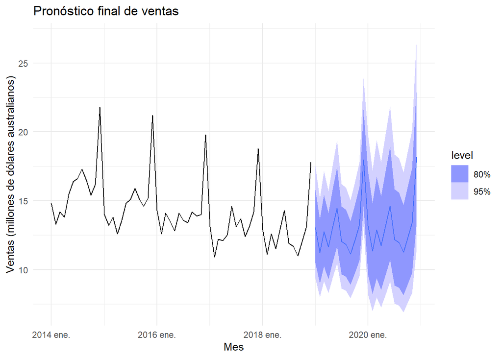

```r
pronostico_final |>
  autoplot(
    electrical_serie |>
      filter(Month >= yearmonth("2014 Jan"))
  ) +
  labs(
    title = "Pronóstico final de ventas",
    x = "Mes",
    y = "Ventas (millones de dólares australianos)"
  ) +
  theme_minimal()
```

El pronóstico de enero de 2019 a diciembre de 2020 indica que las ventas continuarían siguiendo un patrón estacional, con aumentos especialmente marcados en diciembre. Para los primeros meses de 2019, el modelo estima ventas de 13.0 millones de dólares australianos en enero, 11.2 en febrero y 12.7 en marzo. Estas cifras representan una referencia basada en el comportamiento histórico, no ventas observadas. Los intervalos de predicción se amplían conforme avanza el horizonte, por lo que los resultados de los meses más lejanos deben interpretarse con mayor cuidado.

## Conclusiones

Las ventas mensuales de productos eléctricos y electrónicos en Northern Territory presentan una estacionalidad anual marcada, con aumentos pronunciados en diciembre, y una tendencia que creció hasta aproximadamente 2012–2013 antes de disminuir. La transformación Box-Cox redujo las diferencias de variabilidad entre periodos, y la descomposición STL permitió identificar por separado la tendencia, la estacionalidad y las fluctuaciones restantes. Al evaluar los pronósticos frente a los últimos 24 meses observados, el modelo STL + `SNAIVE()` obtuvo menores errores que STL + `RW` con drift: su MAE fue de 1.42 millones de dólares australianos y su RMSE de 1.67, frente a 3.18 y 3.57, respectivamente. Por ello, se seleccionó `SNAIVE()` como modelo baseline y se reentrenó con la serie completa para pronosticar los siguientes 24 meses, de enero de 2019 a diciembre de 2020.

El pronóstico final conserva los incrementos estacionales de diciembre, pero debe interpretarse como una referencia inicial. Los residuales de `SNAIVE()` todavía presentan autocorrelación, lo que indica que el modelo deja patrones temporales sin explicar. Además, los intervalos de predicción se amplían en los meses más lejanos y el método supone que el patrón estacional observado continuará. En una siguiente etapa se podría comparar este baseline con modelos que representen mejor la dependencia entre meses y los cambios de tendencia, como ETS o ARIMA estacional, y evaluar sus pronósticos con el mismo periodo de prueba y las mismas métricas.